# Histograms in R

[Nathaniel E. Helwig](http://stat.umn.edu/~helwig) Department of Psychology & School of Statistics University of Minnesota

Copyright © January 30, 2026

# 1 Introduction

## 1.1 Motivation and Goals

The *histogram* is a simple and useful nonparametric method for estimating the density of an independent and identically distributed (iid) sample of continuous data. Histograms involve placing each observation into one of $m < n$ bins that span the range of the data, and then counting the number of observations within each bin. Once appropriately normalized (by the sample size and bin width), the bin counts provide estimates of the data’s density function, which can be used for visualization purposes. In these notes, I will cover the basics of histogram estimators, including the definition of bin width and break points, as well as provide several examples in R.

## 1.2 Probability Density Functions

### 1.2.1 Definition and Properties

Suppose we have some variable $X \sim f(x)$ where $f(x)$ is the *probability density function* (PDF) of $X$.

Note that we have two requirements on $f(x)$:

1. $f(x)\geq 0$ for all $x \in \mathbb{X}$, where $\mathbb{X}$ is the domain of $X$
2. $\int_{\mathbb{X}} f(x) \mathsf{d}x =1$

In R, density functions are obtained using “d” (for density) plus family abbreviation:

- `dunif()` = uniform density
- `dnorm()` = normal density
- `dt()` = Student’s $t$ density

### 1.2.2 Example 1: Uniform Distribution

The notation $X \sim U[a, b]$ denotes that the random variable $X$ follows a uniform distribution, which has PDF:
$$f(x) = \left\{\begin{array}{cc}
\frac{1}{b-a} & \mathrm{if} \ a \leq x \leq b \\
0 & \mathrm{otherwise} \\
\end{array} \right.$$
where $a$ and $b$ are the lower and upper bounds, respectively. Note that the expected value has the form
$$\mu = E(X) = \int_a^b x f(x) \mathsf{d} x =\frac{1}{2}(a + b)$$
and the variance has the form
$$\sigma^2 = E\left( (X - \mu)^2 \right) = \int_a^b (x - \mu)^2 f(x)
\mathsf{d} x =\frac{1}{12}(b - a)^2$$

If $\mu = 0$ and $\sigma = 1$ (which implies that $a = - \sqrt{3}$ and $b = \sqrt{3}$), we have a standard uniform distribution:

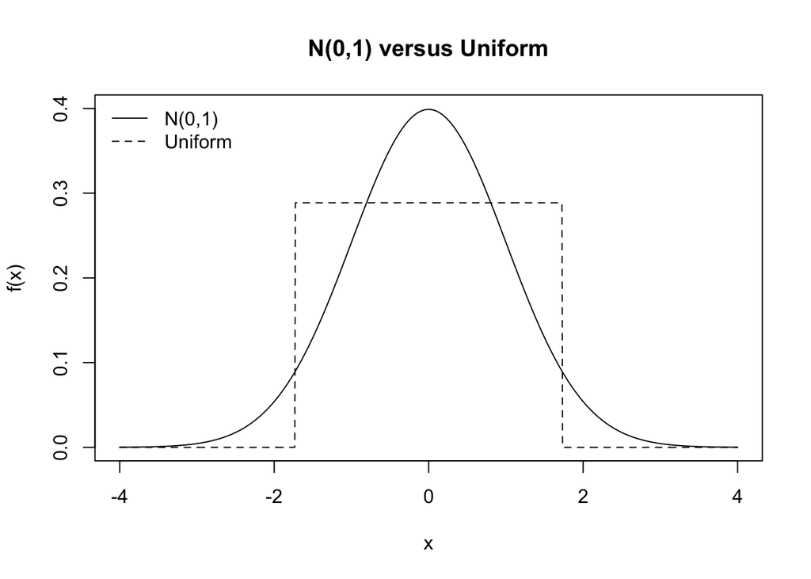

```r
x <- seq(-4, 4, length.out = 1000)
plot(x, dnorm(x), type = "l", xlab = "x", ylab = "f(x)",
     main = "N(0,1) versus Uniform", ylim = c(0, 0.4))
lines(x, dunif(x, -sqrt(3), sqrt(3)), lty = 2)
legend("topleft", c("N(0,1)", "Uniform"), lty = 1:2, bty = "n")
```

### 1.2.3 Example 2: Normal Distribution

The notation $X \sim N(\mu, \sigma^2)$ denotes that the random variable $X$ follows a normal distribution, which has PDF:
$$f(x) = \frac{1}{\sigma\sqrt{2\pi}} \exp\left(
-\frac{(x-\mu)^{2}}{2\sigma^{2}} \right)$$
where $\mu \in \mathbb{R}$ is the expected value, which is defined as
$$\mu = E(X) = \int_{-\infty}^\infty x f(x) \mathsf{d} x$$
and $\sigma^2 \in \mathbb{R}^+$ is the variance, which is defined as
$$\sigma^2 = E\left( (X - \mu)^2 \right) = \int_{-\infty}^\infty (x -
\mu)^2 f(x) \mathsf{d} x$$

If $\mu = 0$ and $\sigma = 1$, we have a standard normal distribution:

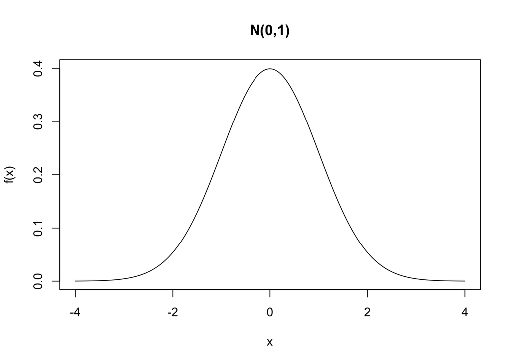

```r
x <- seq(-4, 4, length.out = 1000)
plot(x, dnorm(x), type = "l", xlab = "x", ylab = "f(x)",
     main = "N(0,1)", ylim = c(0, 0.4))
```

### 1.2.4 Example 3: Student’s $t$ Distribution

The notation $X \sim t(\nu)$ denotes that the random variable $X$ follows Student’s $t$ distribution, which has PDF:
$$f(x) = \frac{\Gamma((\nu+1)/2)}{\sqrt{\nu \pi} \Gamma(\nu/2)} \left(1 +
x^2 / \nu \right)^{-(\nu+1)/2}$$
where $\nu$ is the degrees of freedom parameter, and $\Gamma()$ denotes the Gamma function. Note that the expected value has the form
$$\mu = E(X) = \int_{-\infty}^\infty x f(x) \mathsf{d} x = 0$$
and the variance has the form
$$\sigma^2 = E\left( (X - \mu)^2 \right) = \int_{-\infty}^\infty (x -
\mu)^2 f(x) \mathsf{d} x = \left\{ \begin{array}{cc}
\frac{\nu}{\nu - 2} & \mathrm{if } \ \nu > 2 \\
\infty & \mathrm{if } \ 1 < \nu \leq 2 \\
\end{array} \right.$$
and note that the variance is undefined if $\nu \leq 1$.

As $\nu \rightarrow \infty$, we have that $t(\nu) \rightarrow N(0,1)$ in distribution:

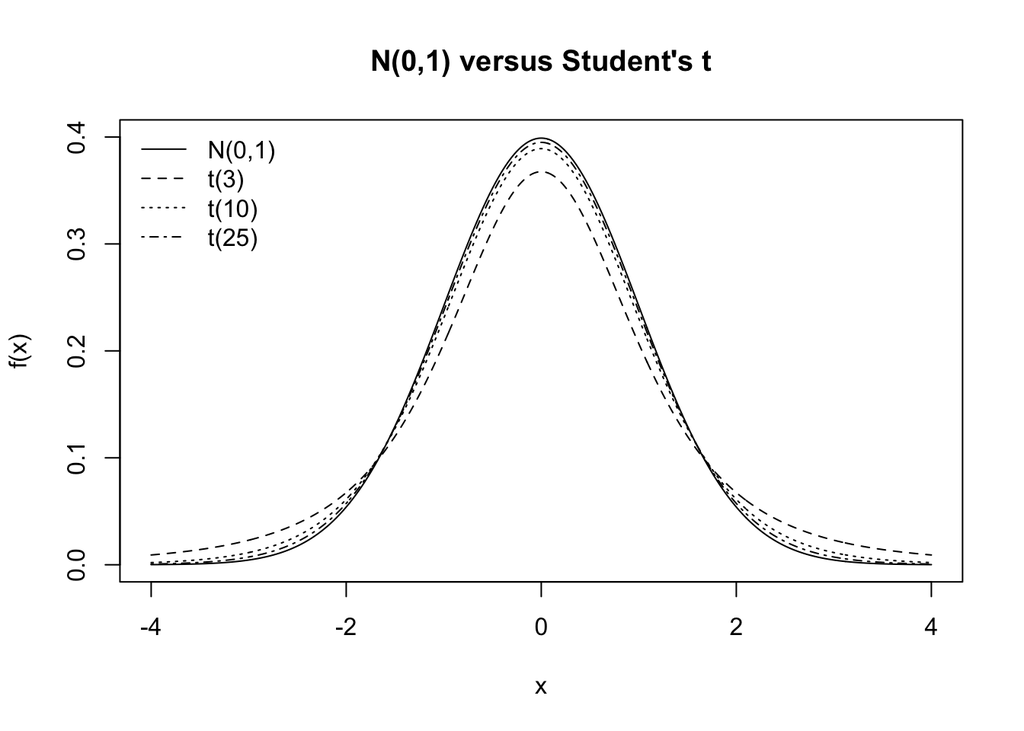

```r
x <- seq(-4, 4, length.out = 1000)
plot(x, dnorm(x), type = "l", xlab = "x", ylab = "f(x)",
     main = "N(0,1) versus Student's t", ylim = c(0, 0.4))
lines(x, dt(x, df = 3), lty = 2)
lines(x, dt(x, df = 10), lty = 3)
lines(x, dt(x, df = 25), lty = 4)
legend("topleft", c("N(0,1)", "t(3)", "t(10)", "t(25)"), lty = 1:4, bty = "n")
```

## 1.3 Cumulative Distribution Functions

Probabilities relate to the area under the PDF:
$$P(a\leq X \leq b) = \int_{a}^{b} f(x) \mathsf{d} x = F(b) - F(a)$$
where
$$F(x) = P(X \leq x) = \int_{-\infty}^{x} f(u) \mathsf{d} u$$
is the *cumulative distribution function* (CDF) of the random variable $X$.

Note that we have two requirements on $F(x)$:

1. $0 \leq F(x) \leq 1$ for all $x \in \mathbb{X}$, where $\mathbb{X}$ is the domain of $X$
2. $F(a) \leq F(b)$ for all $a \leq b$

In R, distribution functions are obtained using “p” (for probability) plus family abbreviation:

- `punif()` = uniform probability distribution
- `pnorm()` = normal probability distribution
- `pt()` = Student’s $t$ probability distribution

### 1.3.1 Example 1: Uniform Distribution

If $X \sim U[a,b]$, then the CDF has the form
$$F(x) = \int_0^x f(x) \mathsf{d} x
= \left\{\begin{array}{cc}
0 & x < a \\
\frac{x - a}{b - a} & a \leq x \leq b \\
1 & x > b
\end{array}\right.$$

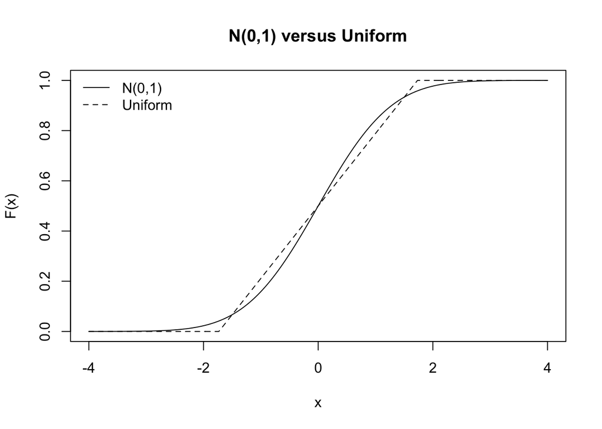

```r
x <- seq(-4, 4, length.out = 1000)
plot(x, pnorm(x), type = "l", xlab = "x", ylab = "F(x)",
     main = "N(0,1) versus Uniform", ylim = c(0, 1))
lines(x, punif(x, -sqrt(3), sqrt(3)), lty = 2)
legend("topleft", c("N(0,1)", "Uniform"), lty = 1:2, bty = "n")
```

### 1.3.2 Example 2: Normal Distribution

If $X \sim N(\mu, \sigma^2)$, then the CDF has the form
$$F(x) = \int_{-\infty}^x f(x) \mathsf{d} x = \Phi\left(\frac{x -
\mu}{\sigma} \right) = \frac{1}{2} \left[1 + \mathrm{erf}\left(\frac{x -
\mu}{\sigma \sqrt{2}}\right) \right]$$
The *standard normal CDF* $\Phi(\cdot)$ is defined as
$$\Phi(x) = \frac{1}{\sqrt{2 \pi}} \int_{-\infty}^x \exp(-u^2/2)
\mathsf{d} u$$
Note: $\Phi(x) = P(X \leq x)$ for a random variable $X \sim N(0, 1)$.

The *error function* is defined as
$$\mathrm{erf}(x) = \frac{1}{\sqrt{\pi}} \int_{-x}^x \exp(-u^2) \mathsf{d}
u = \frac{2}{\sqrt{\pi}} \int_0^x \exp(-u^2) \mathsf{d} u$$
Note: $\mathrm{erf}(x) = P(X \in [-x,x])$ for a random variable $X \sim N(0, 1/2)$.

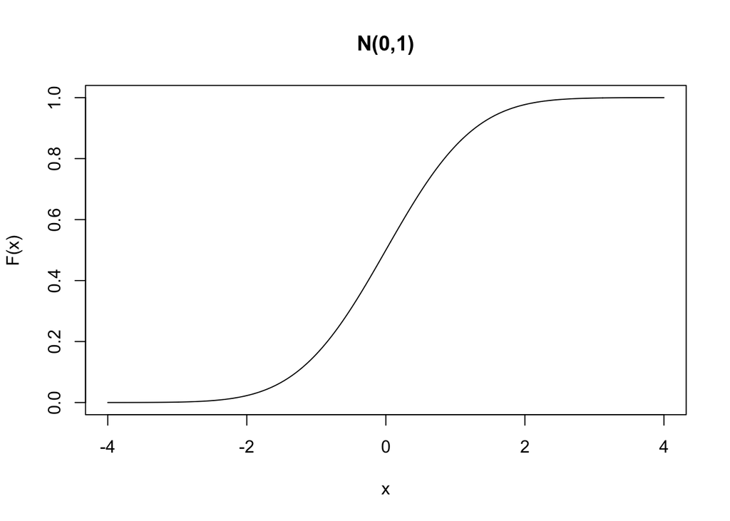

```r
x <- seq(-4, 4, length.out = 1000)
plot(x, pnorm(x), type = "l", xlab = "x", ylab = "F(x)",
     main = "N(0,1)", ylim = c(0, 1))
```

### 1.3.3 Example 3: Student’s $t$ Distribution

If $X \sim t(\nu)$, then the CDF has the form
$$F(x) = \frac{1}{2} + x z \frac{\Gamma((\nu+1)/2)}{\sqrt{\nu \pi}
\Gamma(\nu/2)}$$
where
$$z = {}_2F_1\left(\frac{1}{2}, \frac{\nu+1}{2}; \frac{3}{2};
\frac{-x^2}{\nu} \right)$$
with ${}_2F_1$ denoting the hypergeometric function.

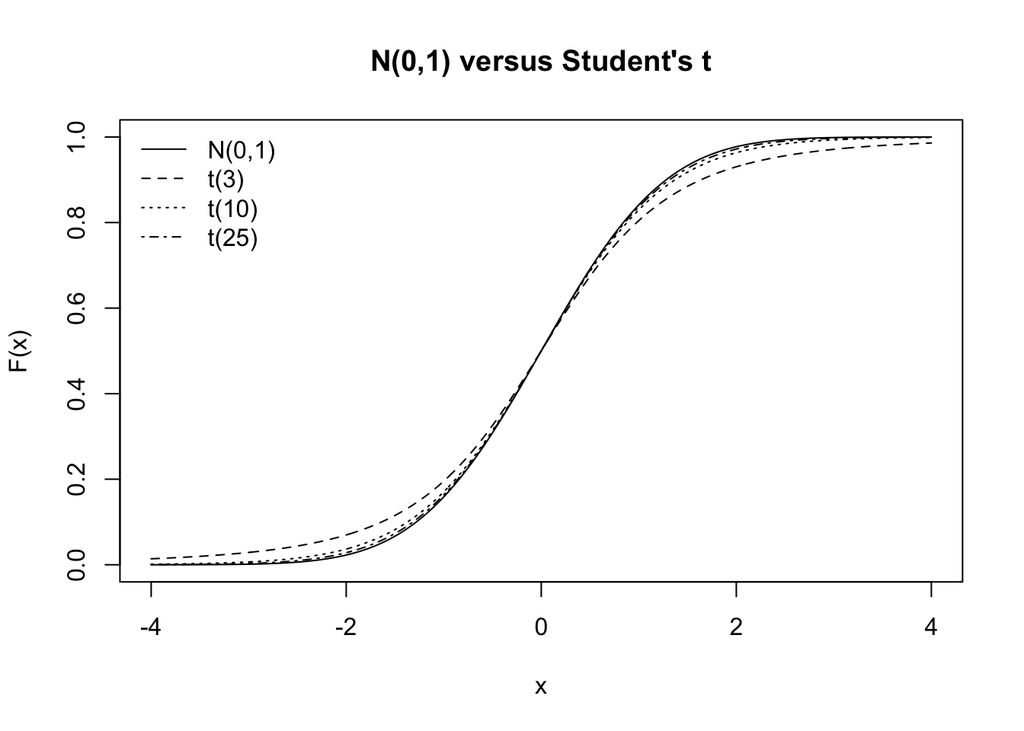

```r
x <- seq(-4, 4, length.out = 1000)
plot(x, pnorm(x), type = "l", xlab = "x", ylab = "F(x)",
     main = "N(0,1) versus Student's t", ylim = c(0, 1))
lines(x, pt(x, df = 3), lty = 2)
lines(x, pt(x, df = 10), lty = 3)
lines(x, pt(x, df = 25), lty = 4)
legend("topleft", c("N(0,1)", "t(3)", "t(10)", "t(25)"), lty = 1:4, bty = "n")
```

# 2 Histograms as Density Estimators

## 2.1 Definition and Properties

### 2.1.1 Bin Widths

If $f(x)$ is smooth, we have that
$$\begin{split}
P(x - h/2 < X < x + h/2) &= F(x + h/2) - F(x - h/2)\\
&= \int_{x - h/2}^{x + h/2} f(z) \mathsf{d}z \\
&\approx hf(x)
\end{split}$$
where $h > 0$ is a small (positive) scalar called the *bin width*. If $F(x)$ were known, we could estimate $f(x)$ using
$$\hat{f}(x) = \frac{1}{h} \left[ F(x+h/2) - F(x - h/2) \right]$$
but this isn’t practical—because if we know the CDF $F$, then we don’t need to estimate the PDF $f$.

### 2.1.2 Bin Width = 1.0

Consider forming a histogram at $x = 0.8043815$ with bin width $h = 1.0$

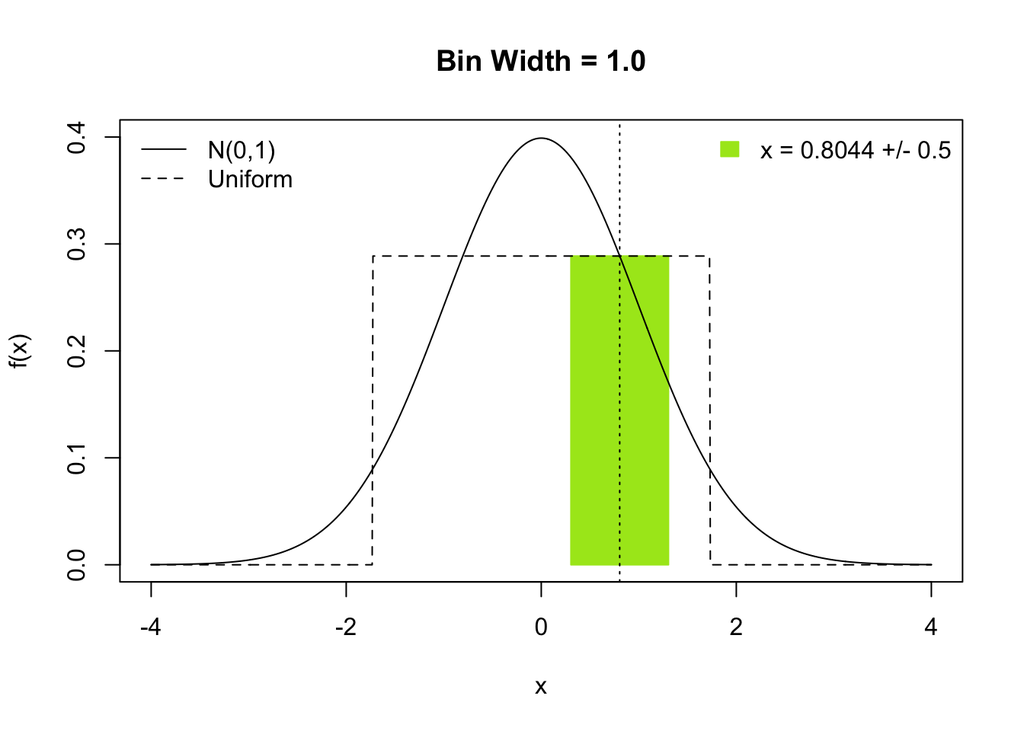

```r
# h = 1.0
x <- seq(-4, 4, length.out = 1000)
plot(x, dnorm(x), type = "n", xlab = "x", ylab = "f(x)",
     main = "Bin Width = 1.0", ylim = c(0, 0.4))
xval <- sqrt( -2*log( sqrt(2 * pi) / (2 * sqrt(3)) ) )
yval <- 1 / (2 * sqrt(3))
hval <- 1.0
mda <- "#A8E61D"
rect(xleft = xval - hval/2, ybottom = 0,
     xright = xval + hval/2, ytop = yval,
     col = mda, border = mda)
abline(v = xval, lty = 3)
legend("topleft", c("N(0,1)", "Uniform"), lty = 1:2, bty = "n")
legend("topright", paste0("x = ", round(xval, 4), " +/- 0.5"),
       fill = mda, border = mda, bty = "n")
lines(x, dnorm(x))
lines(x, dunif(x, -sqrt(3), sqrt(3)), lty = 2)
```

```r
pnorm(xval + hval / 2) - pnorm(xval - hval / 2)       # TRUTH
```

```
## [1] 0.2843669
```

```r
hval * yval                                           # APPROX
```

```
## [1] 0.2886751
```

### 2.1.3 Bin Width = 0.5

Consider forming a histogram at $x = 0.8043815$ with bin width $h = 0.5$

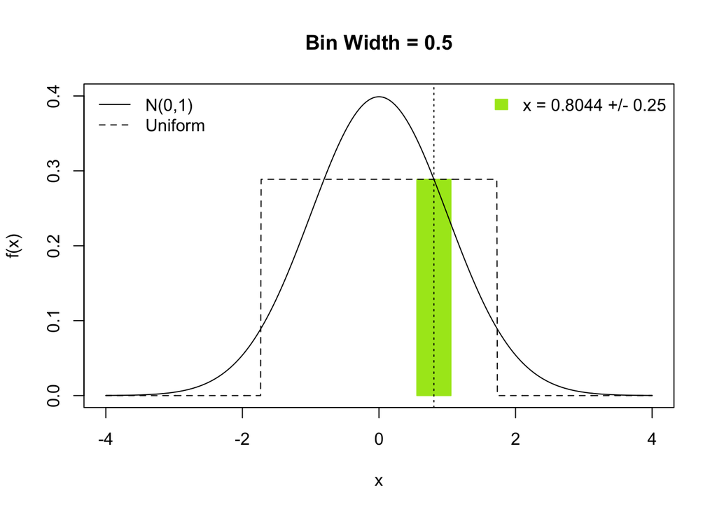

```r
# h = 0.5
x <- seq(-4, 4, length.out = 1000)
plot(x, dnorm(x), type = "n", xlab = "x", ylab = "f(x)",
     main = "Bin Width = 0.5", ylim = c(0, 0.4))
xval <- sqrt( -2*log( sqrt(2 * pi) / (2 * sqrt(3)) ) )
yval <- 1 / (2 * sqrt(3))
hval <- 0.5
mda <- "#A8E61D"
rect(xleft = xval - hval/2, ybottom = 0,
     xright = xval + hval/2, ytop = yval,
     col = mda, border = mda)
abline(v = xval, lty = 3)
legend("topleft", c("N(0,1)", "Uniform"), lty = 1:2, bty = "n")
legend("topright", paste0("x = ", round(xval, 4), " +/- 0.25"),
       fill = mda, border = mda, bty = "n")
lines(x, dnorm(x))
lines(x, dunif(x, -sqrt(3), sqrt(3)), lty = 2)
```

```r
pnorm(xval + hval / 2) - pnorm(xval - hval / 2)       # TRUTH
```

```
## [1] 0.1438047
```

```r
hval * yval                                           # APPROX
```

```
## [1] 0.1443376
```

### 2.1.4 Bin Width = 0.2

Consider forming a histogram at $x = 0.8043815$ with bin width $h = 0.2$:

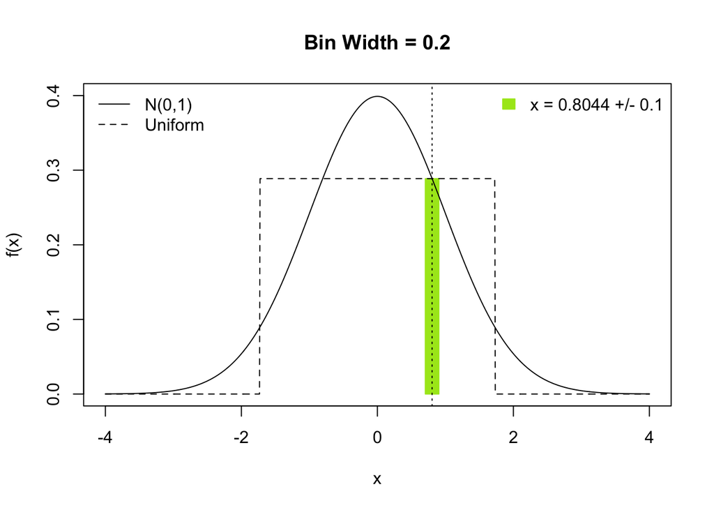

```r
# h = 0.2
x <- seq(-4, 4, length.out = 1000)
plot(x, dnorm(x), type = "n", xlab = "x", ylab = "f(x)",
     main = "Bin Width = 0.2", ylim = c(0, 0.4))
xval <- sqrt( -2*log( sqrt(2 * pi) / (2 * sqrt(3)) ) )
yval <- 1 / (2 * sqrt(3))
hval <- 0.2
mda <- "#A8E61D"
rect(xleft = xval - hval/2, ybottom = 0,
     xright = xval + hval/2, ytop = yval,
     col = mda, border = mda)
abline(v = xval, lty = 3)
legend("topleft", c("N(0,1)", "Uniform"), lty = 1:2, bty = "n")
legend("topright", paste0("x = ", round(xval, 4), " +/- 0.1"),
       fill = mda, border = mda, bty = "n")
lines(x, dnorm(x))
lines(x, dunif(x, -sqrt(3), sqrt(3)), lty = 2)
```

```r
pnorm(xval + hval / 2) - pnorm(xval - hval / 2)       # TRUTH
```

```
## [1] 0.05770104
```

```r
hval * yval                                           # APPROX
```

```
## [1] 0.05773503
```

### 2.1.5 Bin Width = 0.1

Consider forming a histogram at $x = 0.8043815$ with bin width $h = 0.1$:

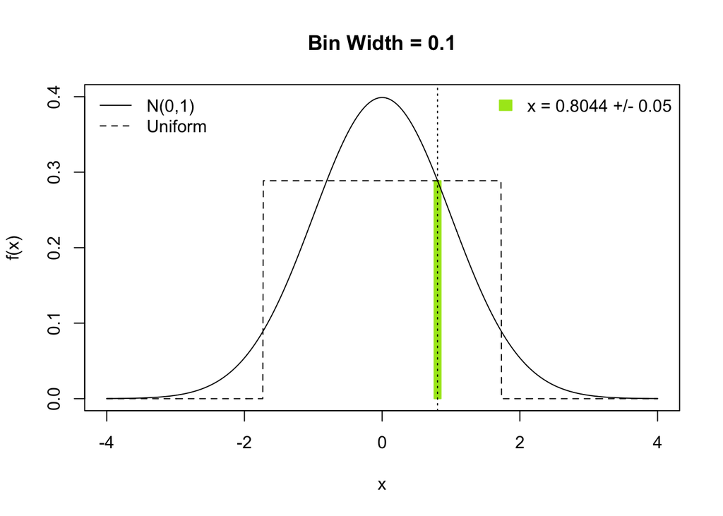

```r
# h = 0.1
x <- seq(-4, 4, length.out = 1000)
plot(x, dnorm(x), type = "n", xlab = "x", ylab = "f(x)",
     main = "Bin Width = 0.1", ylim = c(0, 0.4))
xval <- sqrt( -2*log( sqrt(2 * pi) / (2 * sqrt(3)) ) )
yval <- 1 / (2 * sqrt(3))
hval <- 0.1
mda <- "#A8E61D"
rect(xleft = xval - hval/2, ybottom = 0,
     xright = xval + hval/2, ytop = yval,
     col = mda, border = mda)
abline(v = xval, lty = 3)
legend("topleft", c("N(0,1)", "Uniform"), lty = 1:2, bty = "n")
legend("topright", paste0("x = ", round(xval, 4), " +/- 0.05"),
       fill = mda, border = mda, bty = "n")
lines(x, dnorm(x))
lines(x, dunif(x, -sqrt(3), sqrt(3)), lty = 2)
```

```r
pnorm(xval + hval / 2) - pnorm(xval - hval / 2)       # TRUTH
```

```
## [1] 0.02886327
```

```r
hval * yval                                           # APPROX
```

```
## [1] 0.02886751
```

### 2.1.6 Histogram Definition

If $F(x)$ is unknown we could estimate $f(x)$ using
$$\begin{split}
\hat{f}_n(x) &= \frac{1}{h} \left[ \hat{F}_n(x + h/2) - \hat{F}_n(x
- h/2)\right] \\
&= \frac{1}{n h} \sum_{i=1}^{n} I\left( x_i \in (x - h/2, x + h/2]
\right)
\end{split}$$
where $\hat{F}_n(x) = \frac{1}{n} \sum_{i=1}^{n} I(x_i \leq x)$ is the empirical cumulative distribution function (ECDF). Note: this requires centering a bin (of width $h$) at each input $x$ value. The histogram simplifies this idea by allowing for the bins to be centered at prespecified locations that may depend on the sample of data.

Let $c_1 < c_2 < \cdots < c_{m+1}$ denote $m+1$ chosen *break points* that span the range of the sample of data, i.e.,
$$c_1 \leq \min_i x_i = x_{(1)} \qquad
\mathrm{and} \qquad c_{m+1} \geq \max_i x_i = x_{(n)}$$
Define $m$ bins such as $I_j = (c_j, c_{j+1}]$ for $j = 1, \ldots, m$, and estimate $f(x)$ within the $j$-th bin using
$$\hat{f}_n(x) = \frac{1}{n h} \sum_{i = 1}^{n} I(x_{i} \in I_j) =
\frac{n_j}{nh}$$
for all $x \in I_j$ where $n_j = \sum_{i = 1}^{n} I(x_{i} \in I_j)$ is the number of observations in the $j$-th bin. By default, many softwares define $c_1 = x_{(1)}$ and $I_1 = [c_1, c_2]$ so that $x_{(1)} \in I_1$.

## 2.2 Choosing Bin Widths

### 2.2.1 General Idea

Given an iid sample of data $x_1, \ldots, x_n$, suppose that we want to define $m$ bins that partition the observed range of the data. Given equidistant break points $c_1 < \cdots < c_{m+1}$, we could solve for the bin width such as
$$h = \frac{c_{m+1} - c_1}{m}$$
Conversely, given a desired bin width $h$, we could define the number of bins as
$$m = \left\lceil \frac{x_{(n)} - x_{(1)}}{h} \right\rceil$$
where $\lceil \cdot \rceil$ denotes the ceiling function. Then we can place the break points equidistantly between $x_{(1)}$ and $x_{(n)}$, such as
$$c_j = \left\{ \begin{array}{cc}
x_{(1)} & j = 1 \\
c_{j-1} + h & 2 \leq j \leq m \\
x_{(n)} & j = m + 1 \\
\end{array} \right.$$

Note: you could manually define break points that are not equidistant. If you had prior knowledge about the data distribution (e.g., bell curved), then this knowledge could be used to place more break points in areas with more density. However, all of the automatic bin width selection rules will choose either $m$ or $h$, and then define the break points equidistantly between the min and max sample values.

### 2.2.2 Sturges (1926) Rule

Stuges (1926) proposed choosing the number of bins $m$ using a simple function of the sample size $n$
$$m = \lceil \log_2(n) + 1 \rceil$$
Sturges’s rule is derived under the assumption of normality of $X$ and tends to over-smooth (i.e., choose $m$ that is too small) for non-normal data.

### 2.2.3 Scott (1979) Rule

Scott (1979) proposed choosing the bin width $h$ using a rule that depends on the sample size $n$ and the sample standard deviation:
$$h = (7/2) \hat{\sigma} n^{-1/3}$$
where $\hat{\sigma}^2 = \frac{1}{n-1} \sum_{i=1}^n (x_i - \bar{x})^2$ is the sample variance. Scott’s rule is also derived under the assumption that $X$ is normal.

### 2.2.4 Freedman and Diaconis (1981) Rule

Freedman and Diaconis (1981) proposed choosing the bin width $h$ using a rule that depends on the sample size $n$ and the sample standard deviation:
$$h = 2 \hat{\mathrm{IQR}} n^{-1/3}$$
where $\hat{\mathrm{IQR}}$ is the sample interquartile range, which is used as an estimate of the data’s spread. Note: for normal data, the population IQR is defined as $\mathrm{IQR} = 2 (0.6744898) \sigma$.

## 2.3 Implementation in R

R’s `hist()` function can be used to form histograms from a sample of data.

The `hist()` function has many arguments but only a few are essential in practice:

1. `x` = input vector of data (required)
2. `breaks` = rule to determine $h$, $m$, or values of breaks points
3. `prob` and `freq` = logical toggles for plotting on probability vs frequency scale

Directly from the R help files (`?hist`):

*The `breaks` argument should be one of:*

- *a vector giving the breakpoints between histogram cells,*
- *a function to compute the vector of breakpoints,*
- *a single number giving the number of cells for the histogram,*
- *a character string naming an algorithm to compute the number of cells (see ‘Details’),*
- *a function to compute the number of cells.*

*In the last three cases the number is a suggestion only; as the breakpoints will be set to `pretty()` values, the number is limited to `1e6` (with a warning if it was larger). If `breaks` is a function, the `x` vector is supplied to it as the only argument (and the number of breaks is only limited by the amount of available memory).*

When you use *a character string naming an algorithm to compute the number of cells*, R simply passes the `x` argument to one of the following functions to compute $m$:

- `nclass.Sturges`
- `nclass.scott()`
- `nclass.FD()`

WARNING: unless you manually input the breakpoints, R’s `pretty()` function will likely change the number of bins $m$ or the bin width $h$ that is determined by an automatic rule.

# 3 Examples

## 3.1 Uniform Distribution

### 3.1.1 Bin Width Rules

```r
# generate data
n <- 100
set.seed(1)
x <- runif(n)

# Sturges
nclass.Sturges(x)
```

```
## [1] 8
```

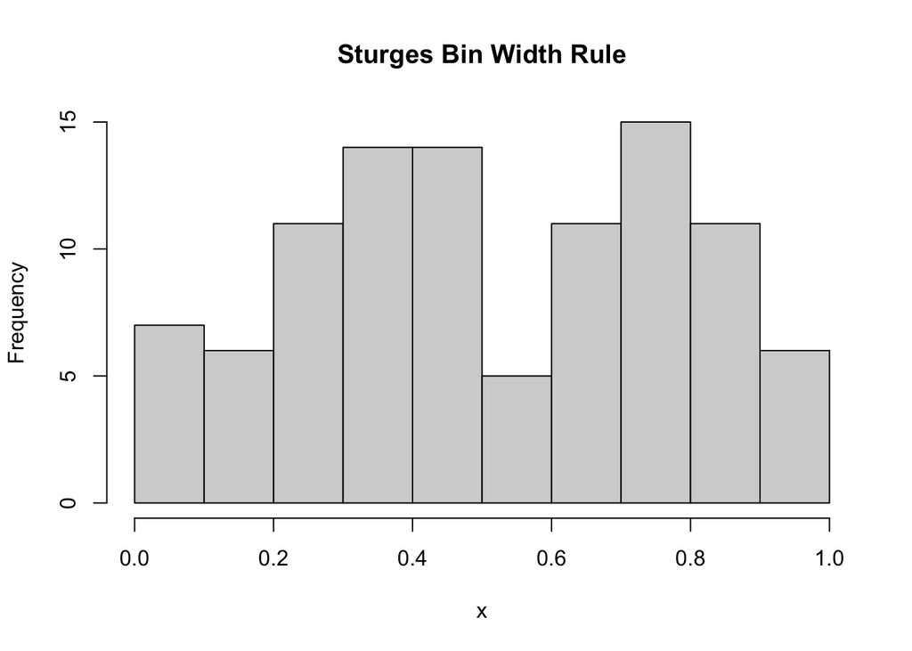

```r
hist(x, breaks = "Sturges", main = "Sturges Bin Width Rule")
```

```r
# Scott
nclass.scott(x)
```

```
## [1] 5
```

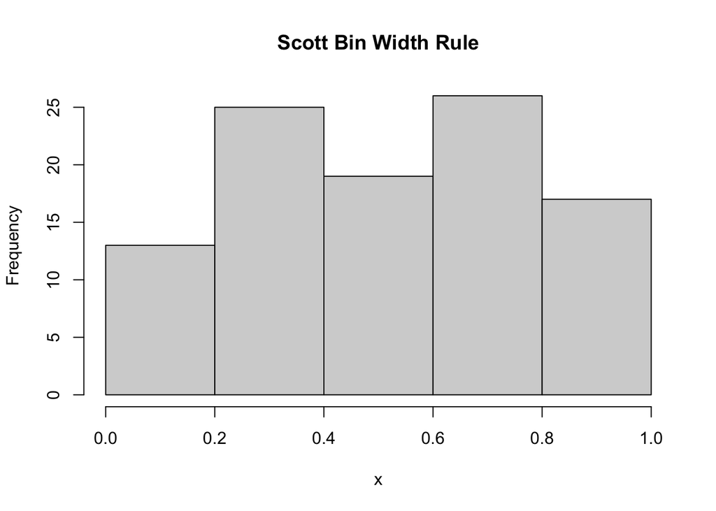

```r
hist(x, breaks = "scott", main = "Scott Bin Width Rule")
```

```r
# Freedman-Diaconis
nclass.FD(x)
```

```
## [1] 6
```

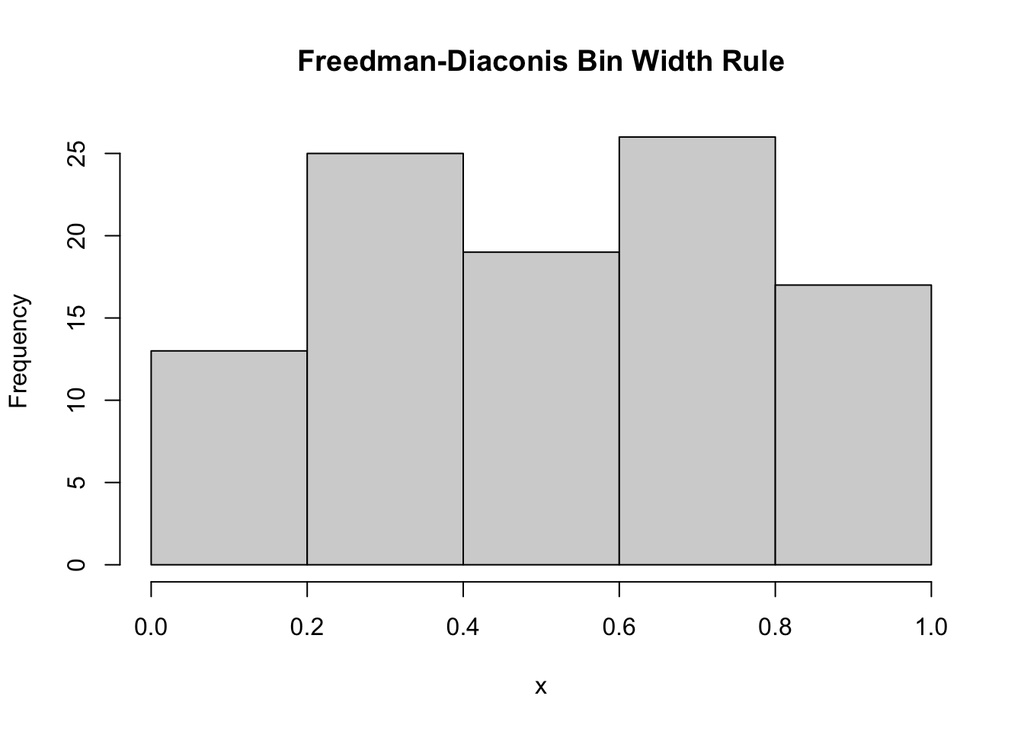

```r
hist(x, breaks = "FD", main = "Freedman-Diaconis Bin Width Rule")
```

Note that R’s `pretty()` function has changed the number of displayed bins for both the Sturges and Freedman-Diaconis rules.

### 3.1.2 Manual Breakpoints

To get breakpoints precisely as specified by the rules, we would need to input the breakpoint values directly.

```r
# generate data
n <- 100
set.seed(1)
x <- runif(n)

# min and max
xmin <- min(x)
xmax <- max(x)

# Sturges
m.Sturges <- nclass.Sturges(x)
m.Sturges
```

```
## [1] 8
```

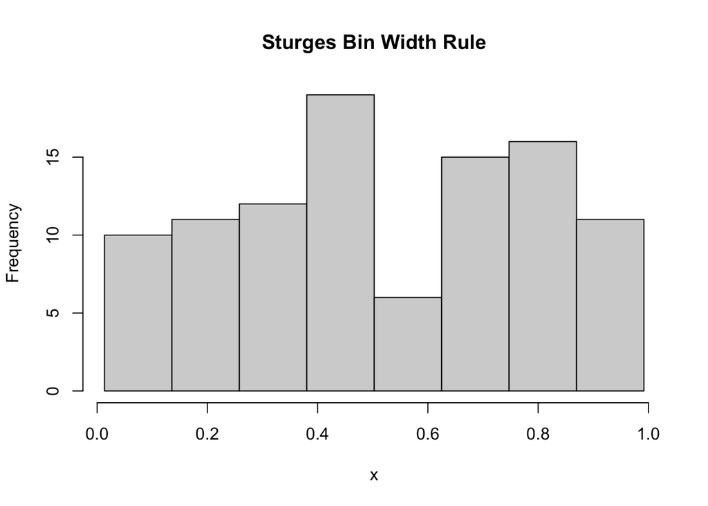

```r
b.Sturges <- seq(xmin, xmax, length.out = m.Sturges + 1)
hist(x, breaks = b.Sturges, main = "Sturges Bin Width Rule")
```

```r
# scott
m.scott <- nclass.scott(x)
m.scott
```

```
## [1] 5
```

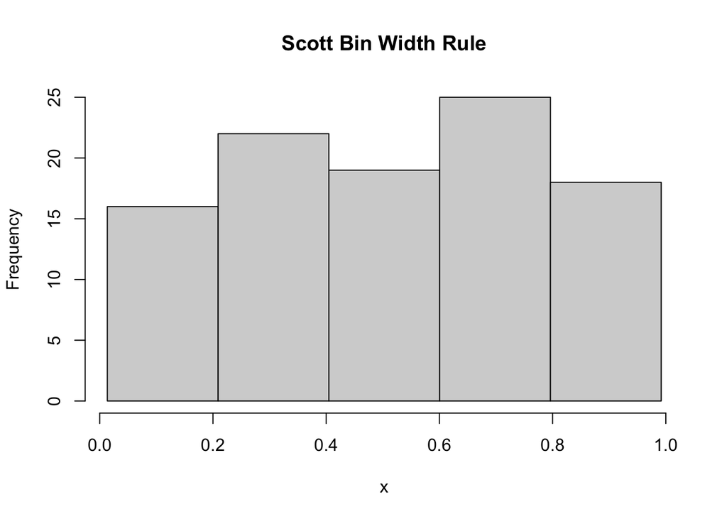

```r
b.scott <- seq(xmin, xmax, length.out = m.scott + 1)
hist(x, breaks = b.scott, main = "Scott Bin Width Rule")
```

```r
# Freedman-Diaconis
m.FD <- nclass.FD(x)
m.FD
```

```
## [1] 6
```

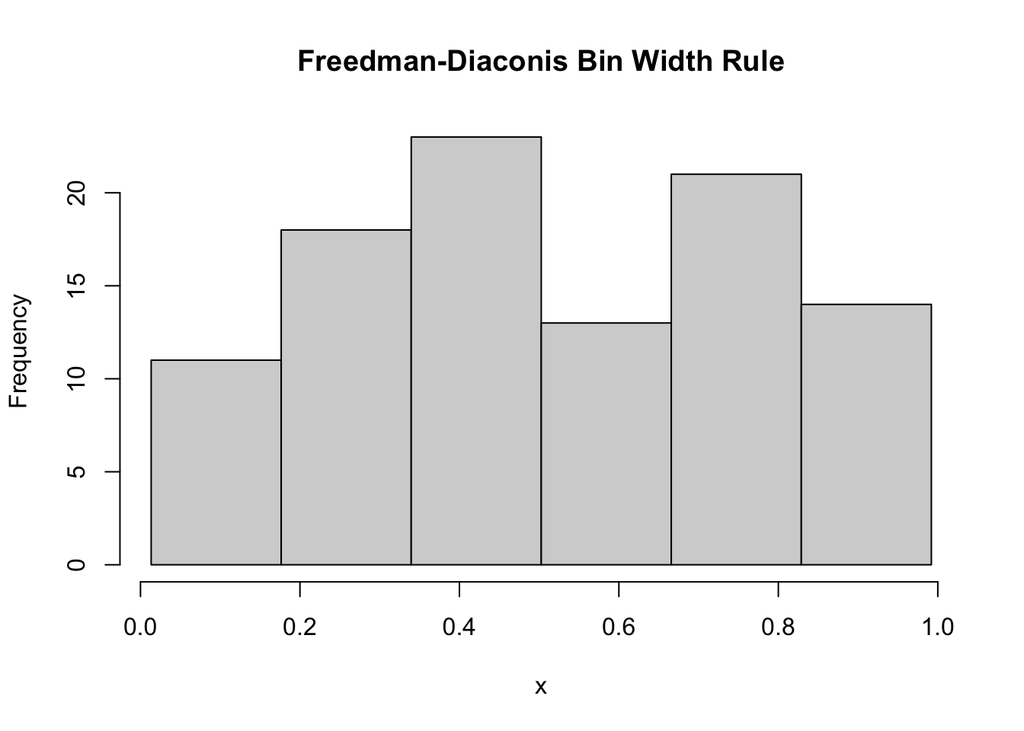

```r
b.FD <- seq(xmin, xmax, length.out = m.FD + 1)
hist(x, breaks = b.FD, main = "Freedman-Diaconis Bin Width Rule")
```

### 3.1.3 Probability Scale

The default in R’s `hist()` function is to plot the frequency within each bin (i.e., $n_j$) on the y-axis. To plot on the density scale, i.e., $n_j/(nh)$, you can use the argument `freq = FALSE` or `prob = TRUE`, which have the same effect:

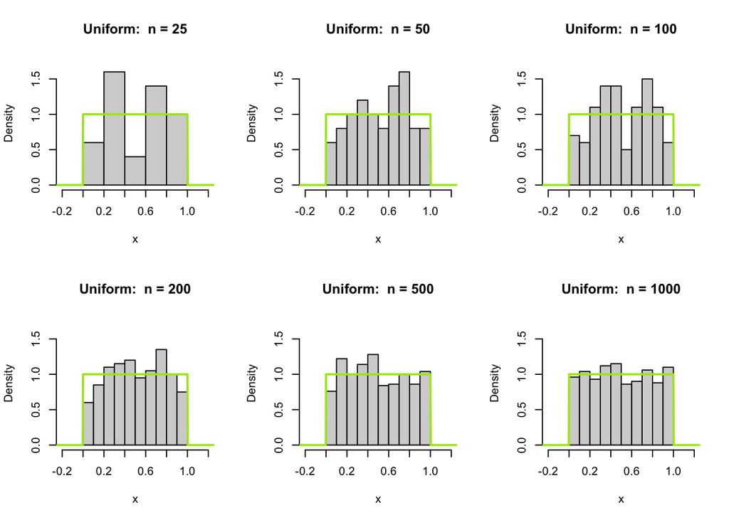

```r
par(mfrow = c(2,3))
xseq <- seq(-1, 2, length.out = 1000)
xlim <- c(-0.2, 1.2)
ylim <- c(0, 1.75)
mda <- "#A8E61D"
for(n in c(25, 50, 100, 200, 500, 1000)){
  set.seed(1)                                                  # set random seed
  x <- runif(n)                                                # sample n from U[0,1]
  xmain <- paste("Uniform:  n =", n)                           # title for plot
  hist(x, prob = TRUE, xlim = xlim, ylim = ylim, main = xmain) # plot hist
  lines(xseq, dunif(xseq), col = mda, lwd = 2)                 # add true PDF
}
```

## 3.2 Normal Distribution

### 3.2.1 Bin Width Rules

```r
# generate data
n <- 100
set.seed(1)
x <- rnorm(n)

# Sturges
nclass.Sturges(x)
```

```
## [1] 8
```

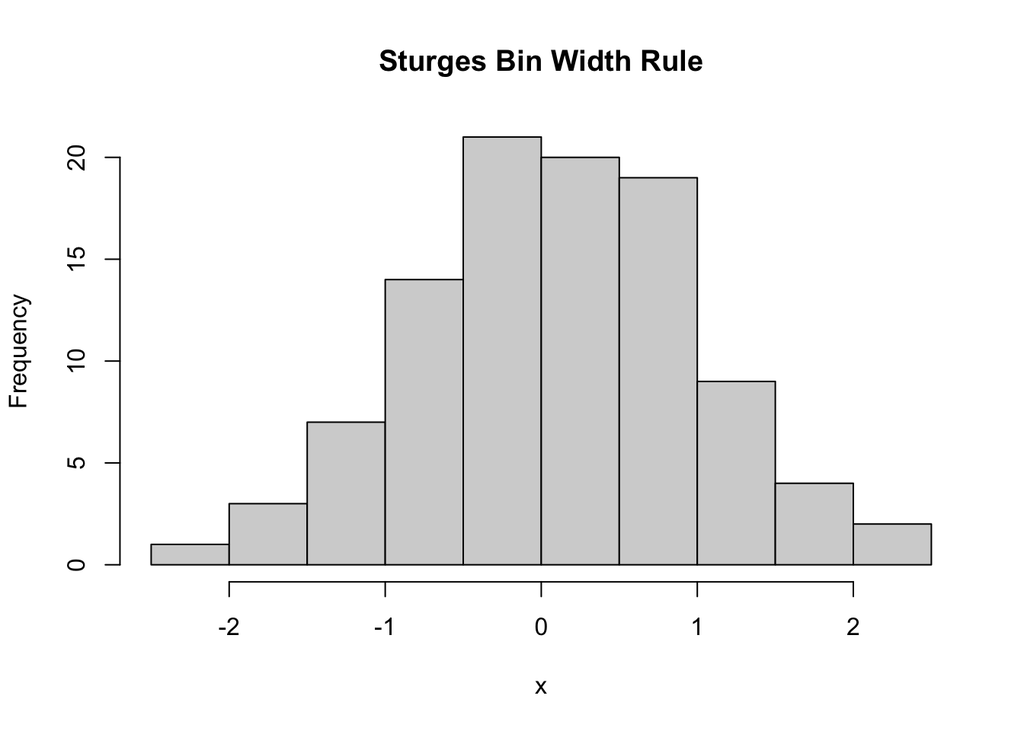

```r
hist(x, breaks = "Sturges", main = "Sturges Bin Width Rule")
```

```r
# Scott
nclass.scott(x)
```

```
## [1] 7
```

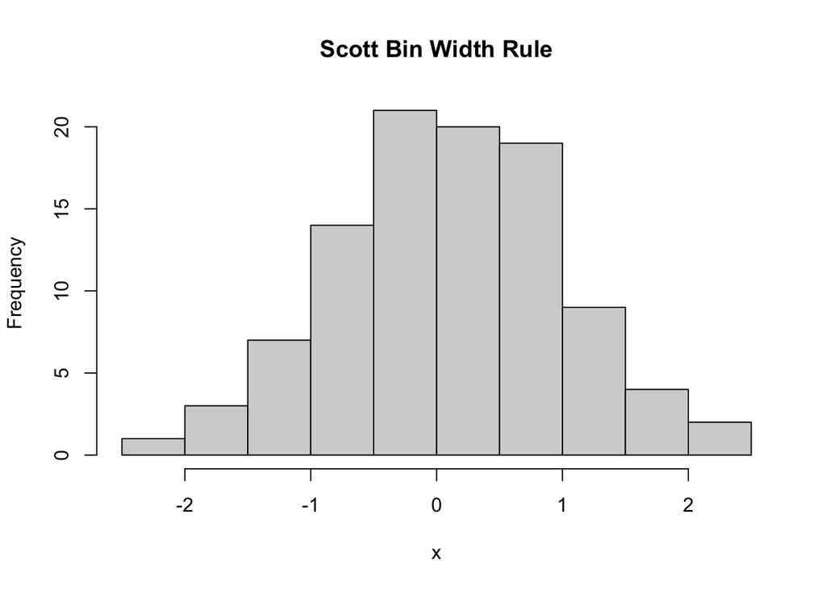

```r
hist(x, breaks = "scott", main = "Scott Bin Width Rule")
```

```r
# Freedman-Diaconis
nclass.FD(x)
```

```
## [1] 10
```

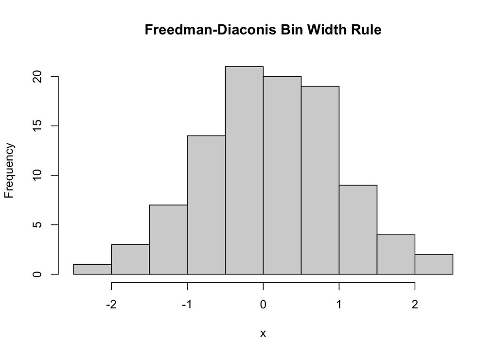

```r
hist(x, breaks = "FD", main = "Freedman-Diaconis Bin Width Rule")
```

Note that R’s `pretty()` function has changed the number of displayed bins for both the Sturges and Scott rules.

### 3.2.2 Manual Breakpoints

To get breakpoints precisely as specified by the rules, we would need to input the breakpoint values directly.

```r
# generate data
n <- 100
set.seed(1)
x <- rnorm(n)

# min and max
xmin <- min(x)
xmax <- max(x)

# Sturges
m.Sturges <- nclass.Sturges(x)
m.Sturges
```

```
## [1] 8
```

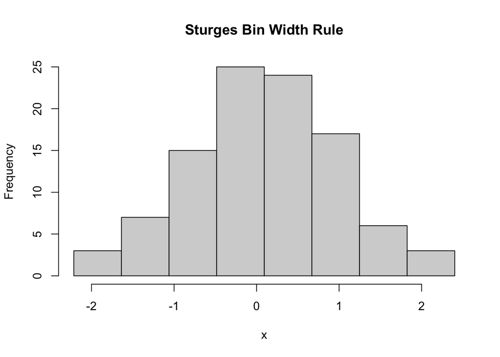

```r
b.Sturges <- seq(xmin, xmax, length.out = m.Sturges + 1)
hist(x, breaks = b.Sturges, main = "Sturges Bin Width Rule")
```

```r
# scott
m.scott <- nclass.scott(x)
m.scott
```

```
## [1] 7
```

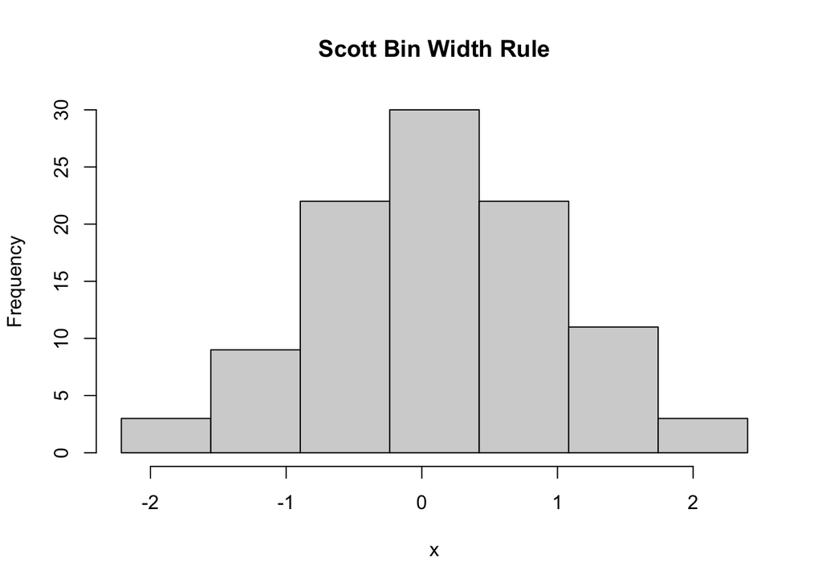

```r
b.scott <- seq(xmin, xmax, length.out = m.scott + 1)
hist(x, breaks = b.scott, main = "Scott Bin Width Rule")
```

```r
# Freedman-Diaconis
m.FD <- nclass.FD(x)
m.FD
```

```
## [1] 10
```

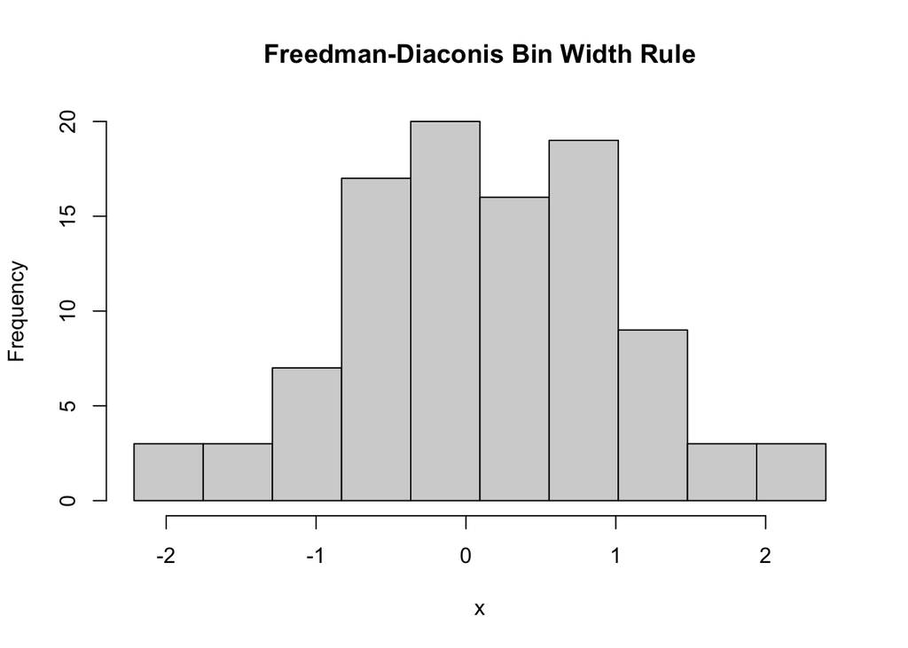

```r
b.FD <- seq(xmin, xmax, length.out = m.FD + 1)
hist(x, breaks = b.FD, main = "Freedman-Diaconis Bin Width Rule")
```

### 3.2.3 Probability Scale

The default in R’s `hist()` function is to plot the frequency within each bin (i.e., $n_j$) on the y-axis. To plot on the density scale, i.e., $n_j/(nh)$, you can use the argument `freq = FALSE` or `prob = TRUE`, which have the same effect:

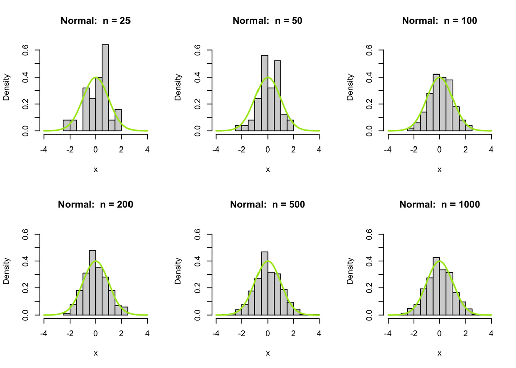

```r
par(mfrow = c(2,3))
xseq <- seq(-4, 4, length.out = 1000)
xlim <- c(-4, 4)
ylim <- c(0, 0.65)
mda <- "#A8E61D"
for(n in c(25, 50, 100, 200, 500, 1000)){
  set.seed(1)                                                  # set random seed
  x <- rnorm(n)                                                # sample n from N(0,1)
  xmain <- paste("Normal:  n =", n)                            # title for plot
  hist(x, prob = TRUE, xlim = xlim, ylim = ylim, main = xmain) # plot hist
  lines(xseq, dnorm(xseq), col = mda, lwd = 2)                 # add true PDF
}
```

## 3.3 Student’s $t$ Distribution

### 3.3.1 Bin Width Rules

```r
# generate data
n <- 100
set.seed(1)
x <- rt(n, df = 3)

# Sturges
nclass.Sturges(x)
```

```
## [1] 8
```

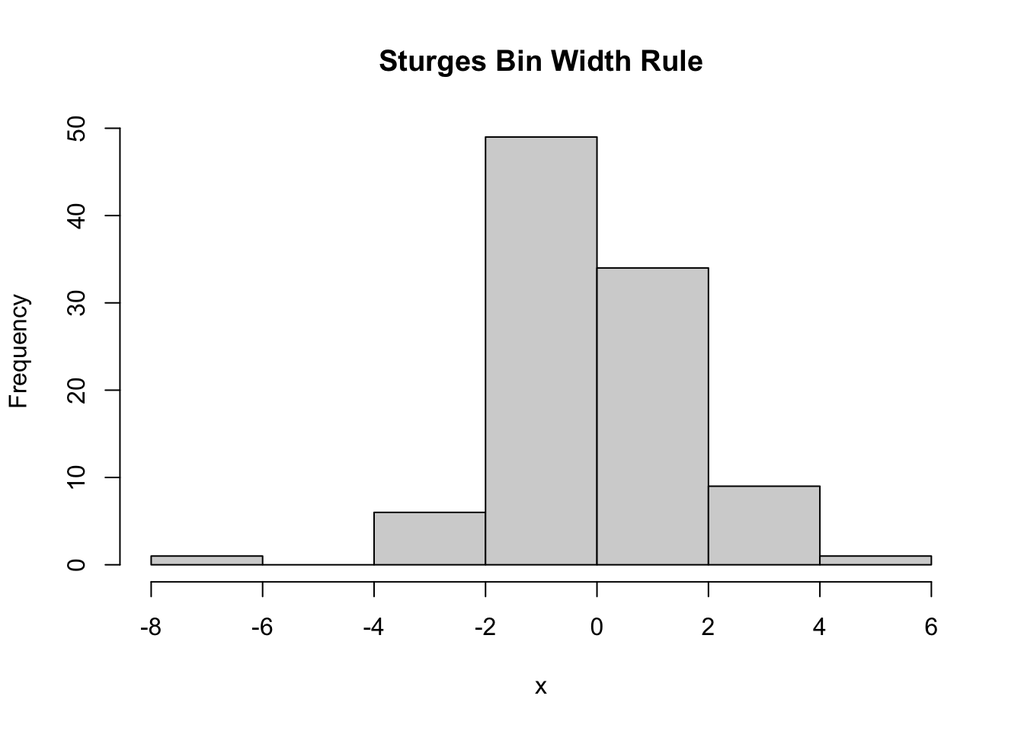

```r
hist(x, breaks = "Sturges", main = "Sturges Bin Width Rule")
```

```r
# Scott
nclass.scott(x)
```

```
## [1] 12
```

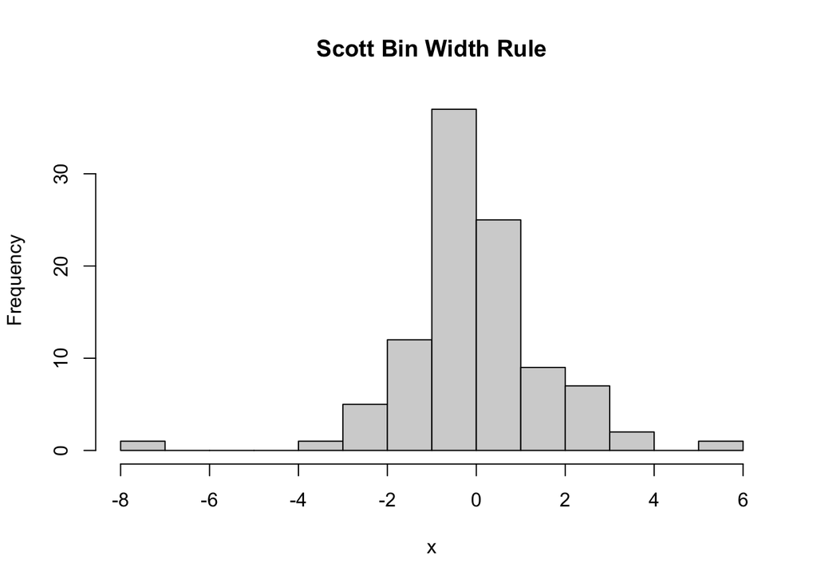

```r
hist(x, breaks = "scott", main = "Scott Bin Width Rule")
```

```r
# Freedman-Diaconis
nclass.FD(x)
```

```
## [1] 21
```

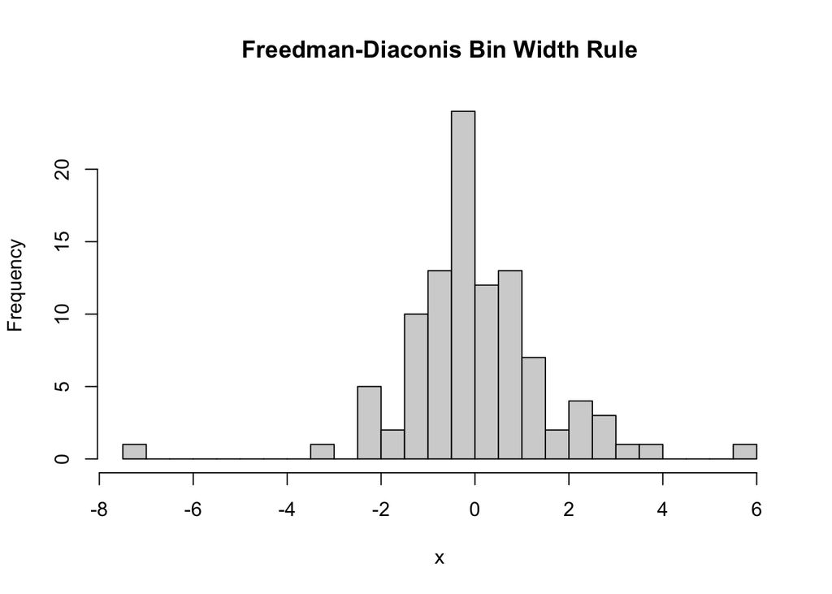

```r
hist(x, breaks = "FD", main = "Freedman-Diaconis Bin Width Rule")
```

Note that R’s `pretty()` function has changed the number of displayed bins for all of the methods.

### 3.3.2 Manual Breakpoints

To get breakpoints precisely as specified by the rules, we would need to input the breakpoint values directly.

```r
# generate data
n <- 100
set.seed(1)
x <- rt(n, df = 3)

# min and max
xmin <- min(x)
xmax <- max(x)

# Sturges
m.Sturges <- nclass.Sturges(x)
m.Sturges
```

```
## [1] 8
```

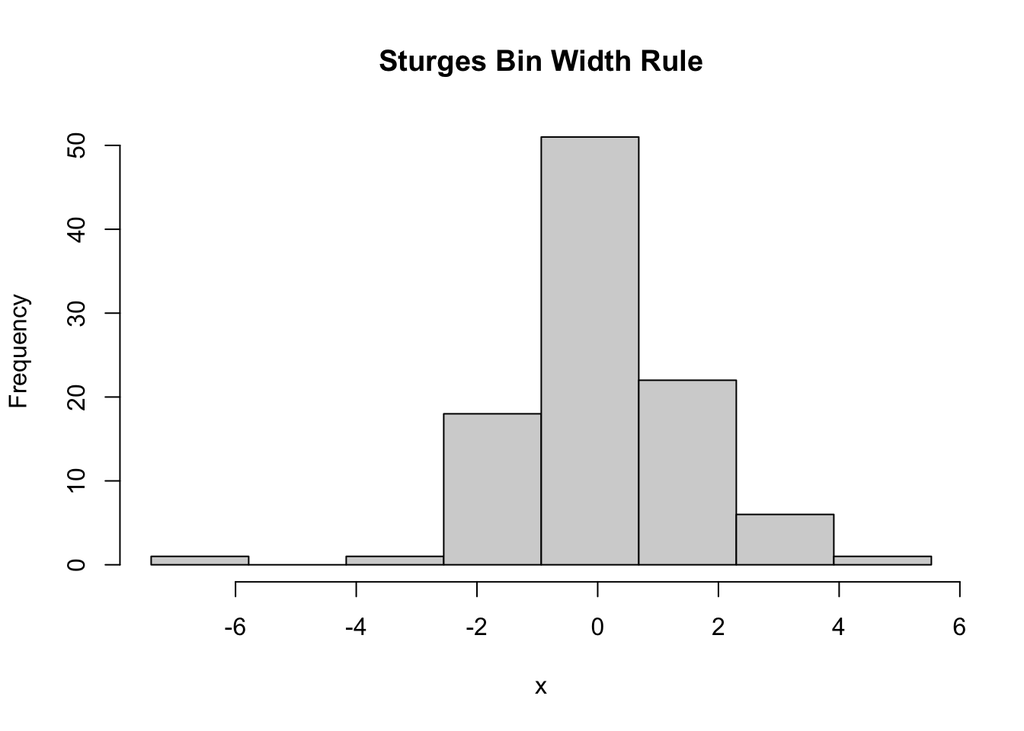

```r
b.Sturges <- seq(xmin, xmax, length.out = m.Sturges + 1)
hist(x, breaks = b.Sturges, main = "Sturges Bin Width Rule")
```

```r
# scott
m.scott <- nclass.scott(x)
m.scott
```

```
## [1] 12
```

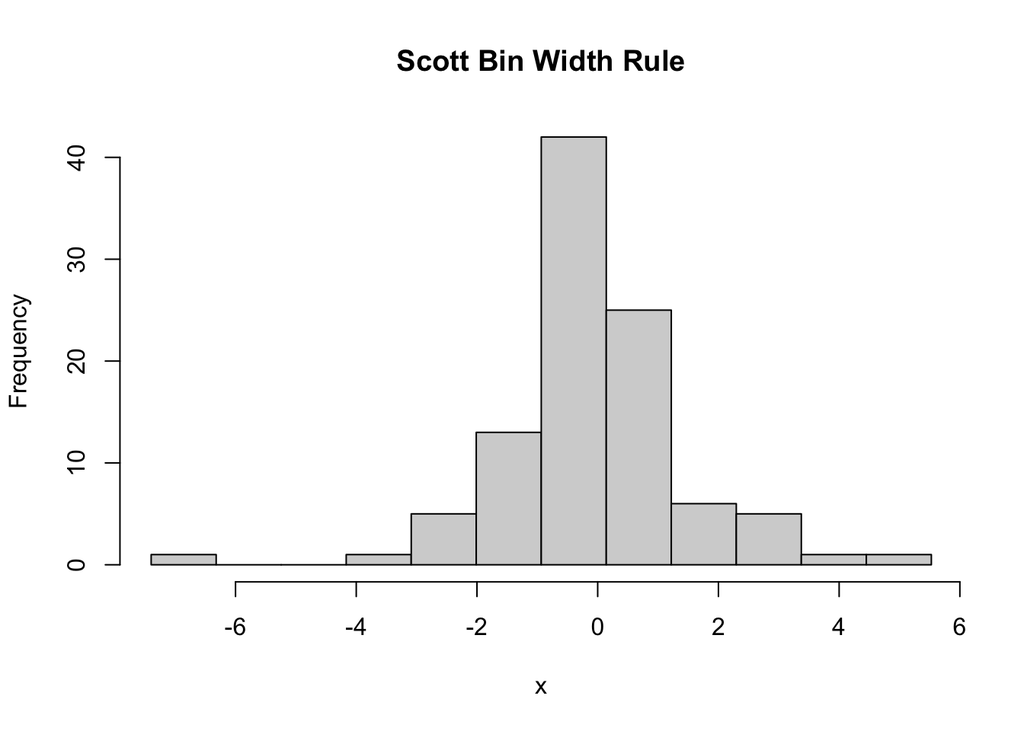

```r
b.scott <- seq(xmin, xmax, length.out = m.scott + 1)
hist(x, breaks = b.scott, main = "Scott Bin Width Rule")
```

```r
# Freedman-Diaconis
m.FD <- nclass.FD(x)
m.FD
```

```
## [1] 21
```

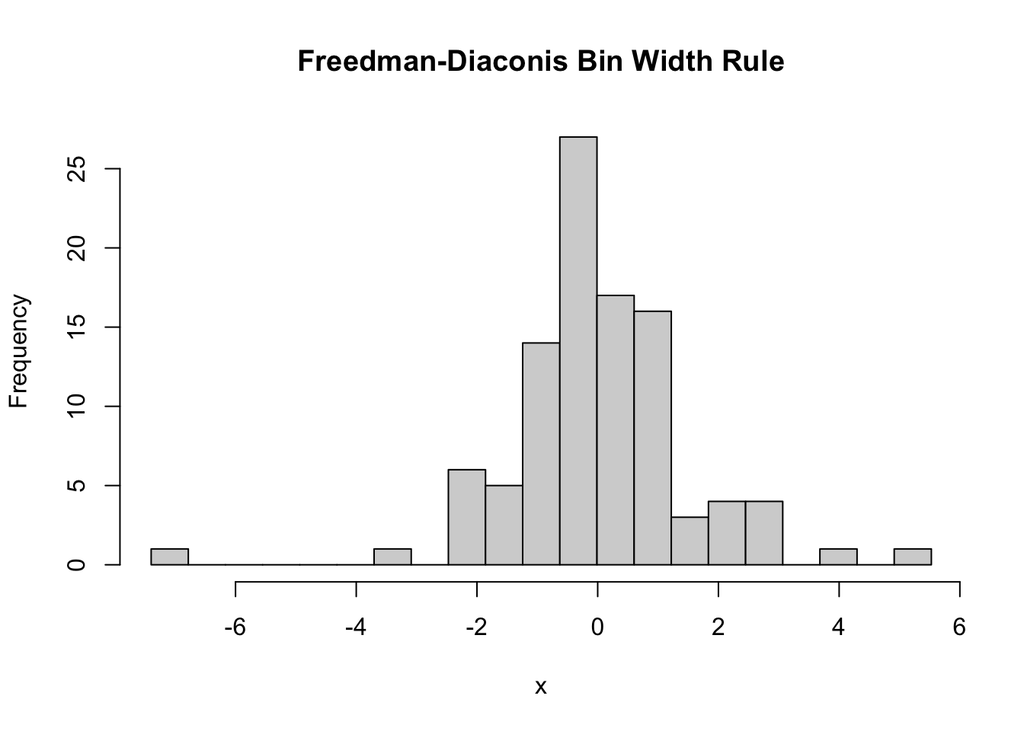

```r
b.FD <- seq(xmin, xmax, length.out = m.FD + 1)
hist(x, breaks = b.FD, main = "Freedman-Diaconis Bin Width Rule")
```